# Proyecto final para el módulo de Visualización de datos

Maribel López Badillo

2025-05-25

```r
# Opciones globales para los chunks de código
knitr::opts_chunk$set(echo = TRUE, message = TRUE, warning = TRUE, fig.align = 'center')


## Cargar librerías necesarias para la manipulación y visualización de datos
library(readr)
library(dplyr)
library(ggplot2)
library(tidyr)
```

# 1 ÁNALISIS ESTADÍSTICO PARA PARÁMETROS DE OPERACIÓN EN COLUMNA DE DESTILACIÓN

## 1.1 PARTE 1. LOS DATOS

### 1.1.1 Cargar los datos

```r
datos <- read.csv("C:/Users/Maribel López Badill/Downloads/dataset_distill.csv", sep = ";", header = TRUE)

## print("Datos cargados exitosamente desde: C:/Users/Maribel López Badill/Downloads/dataset_destill.csv")
```

### 1.1.2 Inspección inicial

```r
print("Estructura general del dataset:")
```

```
## [1] "Estructura general del dataset:"
```

```r
str(datos)
```

```
## 'data.frame':    4150 obs. of  21 variables:
##  $ Pressure: num  1.01 1.01 1.01 1.01 1.01 1.01 1.01 1.01 1.01 1.01 ...
##  $ T1      : num  351 351 351 351 351 ...
##  $ T2      : num  351 351 351 351 351 ...
##  $ T3      : num  351 351 351 351 351 ...
##  $ T4      : num  351 351 351 351 351 ...
##  $ T5      : num  351 351 351 351 351 ...
##  $ T6      : num  351 351 351 351 351 ...
##  $ T7      : num  351 351 351 351 351 ...
##  $ T8      : num  352 351 351 351 351 ...
##  $ T9      : num  352 352 352 352 351 ...
##  $ T10     : num  352 352 352 352 352 ...
##  $ T11     : num  353 353 353 352 352 ...
##  $ T12     : num  355 355 354 354 354 ...
##  $ T13     : num  364 362 360 358 357 ...
##  $ T14     : num  371 371 370 369 368 ...
##  $ L       : int  780 780 780 780 780 780 780 780 780 780 ...
##  $ V       : int  1040 1040 1040 1040 1040 1040 1040 1040 1040 1040 ...
##  $ D       : int  260 260 260 260 260 260 260 260 260 260 ...
##  $ B       : int  340 340 340 340 340 340 340 340 340 340 ...
##  $ F       : int  600 600 600 600 600 600 600 600 600 600 ...
##  $ Ethanol : num  0.821 0.833 0.84 0.844 0.846 ...
```

```r
print("Dimensiones:")
```

```
## [1] "Dimensiones:"
```

```r
print(dim(datos))
```

```
## [1] 4150   21
```

```r
print("Nombres de columnas:")
```

```
## [1] "Nombres de columnas:"
```

```r
print(names(datos))
```

```
##  [1] "Pressure" "T1"       "T2"       "T3"       "T4"       "T5"
##  [7] "T6"       "T7"       "T8"       "T9"       "T10"      "T11"
## [13] "T12"      "T13"      "T14"      "L"        "V"        "D"
## [19] "B"        "F"        "Ethanol"
```

```r
print("Resumen estadístico:")
```

```
## [1] "Resumen estadístico:"
```

```r
summary(datos)
```

```
##     Pressure          T1              T2              T3              T4
##  Min.   :1.01   Min.   :350.8   Min.   :350.8   Min.   :350.8   Min.   :350.8
##  1st Qu.:1.01   1st Qu.:350.8   1st Qu.:350.9   1st Qu.:350.9   1st Qu.:350.9
##  Median :1.01   Median :350.9   Median :351.0   Median :351.1   Median :351.2
##  Mean   :1.01   Mean   :351.0   Mean   :351.4   Mean   :352.1   Mean   :352.8
##  3rd Qu.:1.01   3rd Qu.:351.1   3rd Qu.:351.4   3rd Qu.:351.8   3rd Qu.:352.2
##  Max.   :1.01   Max.   :352.3   Max.   :356.0   Max.   :365.0   Max.   :368.6
##        T5              T6              T7              T8
##  Min.   :350.8   Min.   :350.8   Min.   :350.9   Min.   :350.9
##  1st Qu.:351.0   1st Qu.:351.1   1st Qu.:351.1   1st Qu.:351.3
##  Median :351.4   Median :351.7   Median :352.1   Median :352.7
##  Mean   :353.6   Mean   :354.6   Mean   :355.7   Mean   :356.7
##  3rd Qu.:353.2   3rd Qu.:355.2   3rd Qu.:359.2   3rd Qu.:361.6
##  Max.   :369.1   Max.   :371.5   Max.   :372.8   Max.   :372.9
##        T9             T10             T11             T12
##  Min.   :351.0   Min.   :351.2   Min.   :351.5   Min.   :352.4
##  1st Qu.:351.4   1st Qu.:351.7   1st Qu.:352.1   1st Qu.:353.2
##  Median :353.1   Median :353.9   Median :354.4   Median :358.0
##  Mean   :357.7   Mean   :358.5   Mean   :359.3   Mean   :360.1
##  3rd Qu.:365.1   3rd Qu.:366.8   3rd Qu.:367.4   3rd Qu.:367.4
##  Max.   :372.9   Max.   :372.9   Max.   :372.9   Max.   :372.9
##       T13             T14              L               V
##  Min.   :353.1   Min.   :354.5   Min.   :   75   Min.   :  225
##  1st Qu.:354.8   1st Qu.:362.9   1st Qu.:  450   1st Qu.:  600
##  Median :368.6   Median :372.5   Median :  780   Median : 1040
##  Mean   :363.8   Mean   :367.4   Mean   : 2230   Mean   : 2475
##  3rd Qu.:372.3   3rd Qu.:373.0   3rd Qu.: 1050   3rd Qu.: 1400
##  Max.   :373.1   Max.   :373.1   Max.   :22500   Max.   :22650
##        D               B             F            Ethanol
##  Min.   :150.0   Min.   : 90   Min.   :350.0   Min.   :0.5382
##  1st Qu.:150.0   1st Qu.:200   1st Qu.:350.0   1st Qu.:0.7629
##  Median :260.0   Median :340   Median :600.0   Median :0.8206
##  Mean   :245.7   Mean   :293   Mean   :538.7   Mean   :0.7924
##  3rd Qu.:260.0   3rd Qu.:390   3rd Qu.:600.0   3rd Qu.:0.8508
##  Max.   :350.0   Max.   :450   Max.   :650.0   Max.   :0.8918
```

### 1.1.3 Limpieza

```r
## Eliminar filas completamente vacías
datos <- datos %>% drop_na()

## Reemplazar valores NA con la media (solo numéricos)
datos <- datos %>%
  mutate(across(where(is.numeric), ~ ifelse(is.na(.), mean(., na.rm = TRUE), .)))
```

## 1.2 PARTE 2. DEFINICIÓN DEL PROBLEMA Y SELECCIÓN DEL DATASET

### 1.2.3 JUSTIFICACIÓN

Este conjunto de datos, compuesto por valores continuos, describe el comportamiento de una columna de destilación, lo cual es de gran relevancia en la ingeniería de procesos. Su disponibilidad para descargar, visualización, manipulación y análisis lo convierte en una herramienta valiosa. A pesar de ser simulados, los datos incorporan ruido y valores faltantes intencionales con fines de entrenamiento, representando así condiciones industriales reales.

La fuente del dataset provienen de un artículo científico con revisión por pares, compartido por lo autores en la plataforma de ciencia de datos Kaggle, lo que garantiza su fiabilidad. Es un conjunto de datos simulado, que incorpora ruido, valores atípicos y datos faltantes para representar condiciones industriales reales. Los valores del dataset son variables numéricas continuas. Todas estas características permitirán la imputación y visualización de distribuciones reales del proceso.

El enelace par aobtener los datos es el siguiente:

[conjunto de datos_distill.csv](https://www.kaggle.com/code/hajaribrahiem/ml-distillation-column-lr-svr/input?select=dataset_distill.csv)

Referencia

Cote-Ballesteros, J.E., Grisales Palacios, V.H. y Rodríguez-Castellanos, J.E. (2022). Un algoritmo de selección de variables de enfoque híbrido basado en información mutua para aplicaciones de sensores blandos industriales basados en datos. Ciencia e Ingeniería Neogranadina, 32(1), 59–70. https://doi.org/10.18359/rcin.5644

## 1.3 PARTE 3. TRANSFORMACIÓN DE DATOS

```r
## Crear nueva variable: relación entre D y L (Reflujo)
datos <- datos %>%
  mutate(reflujo = D / L)

## Verificar la nueva variable
print("Primeros valores del reflujo:")
```

```
## [1] "Primeros valores del reflujo:"
```

```r
head(datos$reflujo)
```

```
## [1] 0.3333333 0.3333333 0.3333333 0.3333333 0.3333333 0.3333333
```

```r
## CREAR COLUMNA DE TIEMPO
datos <- datos %>%
  mutate(Tiempo_h = seq(0, by = 0.1, length.out = n()))

## Confirmar las nuevas columnas
print("Primeras filas con nuevas columnas (Tiempo_h y reflujo):")
```

```
## [1] "Primeras filas con nuevas columnas (Tiempo_h y reflujo):"
```

```r
head(datos)
```

|  | Pressure | T1 | T2 | T3 | T4 | T5 | T6 | T7 | T8 | T9 | T10 | T11 | T12 | T13 | T14 | L | V | D | B | F | Ethanol | reflujo | Tiempo_h |
| --- | --- | --- | --- | --- | --- | --- | --- | --- | --- | --- | --- | --- | --- | --- | --- | --- | --- | --- | --- | --- | --- | --- | --- |
| 1 | 1.01 | 350.89 | 350.95 | 351.01 | 351.08 | 351.16 | 351.26 | 351.38 | 351.54 | 351.78 | 352.18 | 353.00 | 355.19 | 363.77 | 371.47 | 780 | 1040 | 260 | 340 | 600 | 0.82076 | 0.3333333 | 0.0 |
| 2 | 1.01 | 350.86 | 350.91 | 350.96 | 351.02 | 351.09 | 351.17 | 351.28 | 351.43 | 351.66 | 352.03 | 352.76 | 354.66 | 362.20 | 370.98 | 780 | 1040 | 260 | 340 | 600 | 0.83253 | 0.3333333 | 0.1 |
| 3 | 1.01 | 350.85 | 350.89 | 350.93 | 350.99 | 351.05 | 351.13 | 351.23 | 351.37 | 351.58 | 351.91 | 352.55 | 354.13 | 360.16 | 370.10 | 780 | 1040 | 260 | 340 | 600 | 0.83953 | 0.3333333 | 0.2 |
| 4 | 1.01 | 350.84 | 350.88 | 350.92 | 350.97 | 351.03 | 351.11 | 351.21 | 351.34 | 351.53 | 351.83 | 352.40 | 353.75 | 358.45 | 368.99 | 780 | 1040 | 260 | 340 | 600 | 0.84366 | 0.3333333 | 0.3 |
| 5 | 1.01 | 350.83 | 350.87 | 350.91 | 350.96 | 351.02 | 351.09 | 351.18 | 351.31 | 351.49 | 351.78 | 352.30 | 353.50 | 357.23 | 367.81 | 780 | 1040 | 260 | 340 | 600 | 0.84622 | 0.3333333 | 0.4 |
| 6 | 1.01 | 350.83 | 350.86 | 350.91 | 350.95 | 351.01 | 351.08 | 351.17 | 351.29 | 351.47 | 351.74 | 352.23 | 353.33 | 356.41 | 366.69 | 780 | 1040 | 260 | 340 | 600 | 0.84788 | 0.3333333 | 0.5 |

## 1.4 PARTE 4. VISUALIZACIONES Y PUBLICACIÓN

### 1.4.1 Perfiles de temperatura para sensores pares

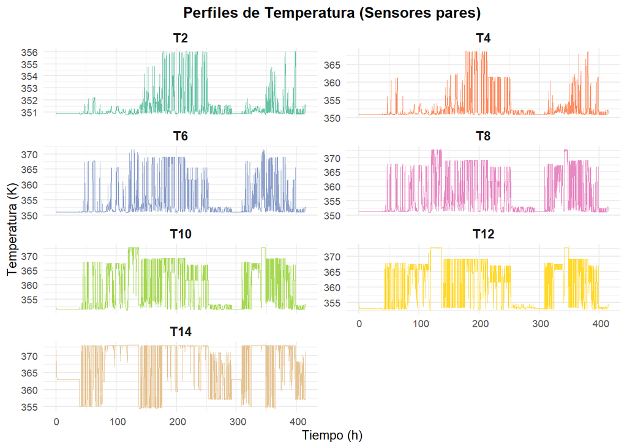

```r
## Transformar los datos a formato largo para ggplot
datos_perfil_temp <- datos %>%
  select(Tiempo_h, starts_with("T")) %>% # Selecciona Tiempo_h y todas las columnas que empiezan con T
  pivot_longer(cols = -Tiempo_h, names_to = "Sensor", values_to = "Temperatura") %>%
  # Filtrar para incluir solo los sensores pares especificados
  filter(Sensor %in% c("T2", "T4", "T6", "T8", "T10", "T12", "T14")) %>%
  # Asegurar un orden lógico para los sensores en los gráficos
  mutate(Sensor = factor(Sensor, levels = paste0("T", c(2, 4, 6, 8, 10, 12, 14))))

ggplot(datos_perfil_temp, aes(x = Tiempo_h, y = Temperatura, color = Sensor)) +
  geom_line(linewidth = 0.3) +
  facet_wrap(~Sensor, scales = "free_y", ncol = 2) +
  labs(
    title = "Perfiles de Temperatura (Sensores pares)",
    x = "Tiempo (h)",
    y = "Temperatura (K)"
  ) +
  scale_color_brewer(palette = "Set2") +
  theme_minimal(base_size = 10) +
  theme(
    axis.text.x = element_text(angle = 0, hjust = 0.4),
    strip.text = element_text(size = 10, face = "bold"),
    legend.position = "none",
    plot.title = element_text(hjust = 0.5, face = "bold")
  )
```

**Análisis perfiles de temperaturas:**

Los datos sugieren que la columna de destilación experimenta fluctuaciones significativas en sus perfiles de temperatura, lo que podría indicar inestabilidad en el proceso o una operación lejos de un estado estacionario ideal.

### 1.4.2 Histograma comparativo para T1 y T14

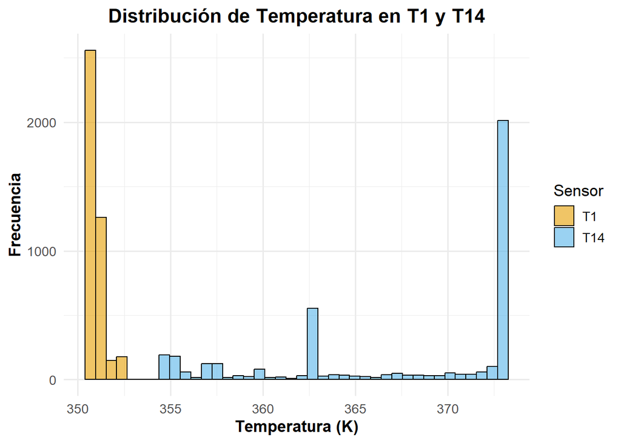

```r
ggplot(datos) +
  geom_histogram(aes(x = T1, fill = "T1"), bins = 40, alpha = 0.6, color = "black") +
  geom_histogram(aes(x = T14, fill = "T14"), bins = 40, alpha = 0.6, color = "black") +
  scale_fill_manual(values = c("T1" = "#E69F00", "T14" = "#56B4E9")) +
  labs(
    title = "Distribución de Temperatura en T1 y T14",
    x = "Temperatura (K)",
    y = "Frecuencia",
    fill = "Sensor"
  ) +
  theme_minimal(base_size = 13) +
  theme(
    plot.title = element_text(face = "bold", hjust = 0.5),
    axis.title = element_text(face = "bold")
  )
```

**Análisis histogramas para T1 y T14:**

La distribución de temperaturas entre T1 y T14 confirma la existencia de un gradiente térmico esperado.

### 1.4.3 Histograma de concentración de etanol

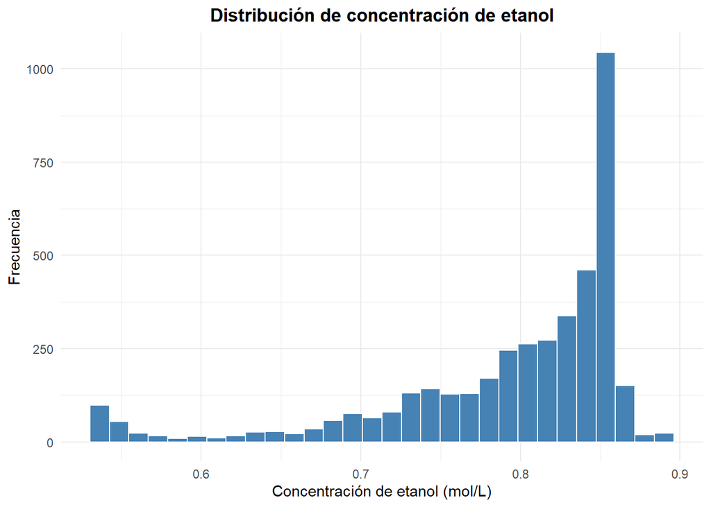

```r
ggplot(datos, aes(x = Ethanol)) +
  geom_histogram(bins = 30, fill = "steelblue", color = "white") +
  labs(title = "Distribución de concentración de etanol",
       x = "Concentración de etanol (mol/L)",
       y = "Frecuencia") +
  theme_minimal() +
  theme(plot.title = element_text(hjust = 0.5, face = "bold"))
```

### 1.4.4 Dispersión entre temperaturas (T1, T4, T10, T14) y caudal de alimentación (F)

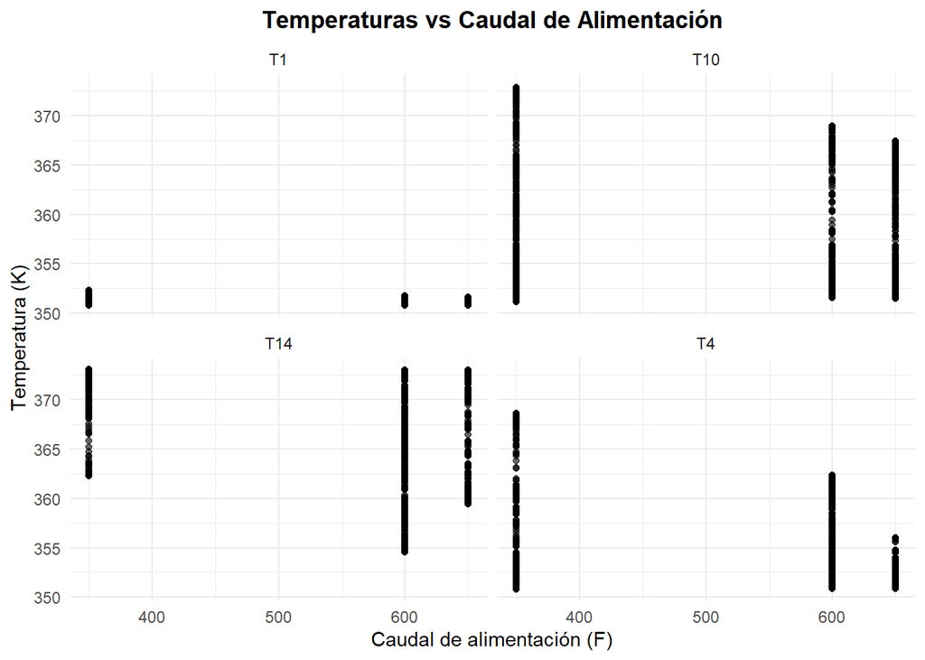

```r
datos_largos <- datos %>%
  select(F, T1, T4, T10, T14) %>%
  pivot_longer(cols = -F, names_to = "Sensor", values_to = "Temperatura")

ggplot(datos_largos, aes(x = F, y = Temperatura)) +
  geom_point(alpha = 0.6) +
  facet_wrap(~Sensor) +
  labs(title = "Temperaturas vs Caudal de Alimentación",
       x = "Caudal de alimentación (F)",
       y = "Temperatura (K)") +
  theme_minimal() +
  theme(plot.title = element_text(hjust = 0.5, face = "bold"))
```

**Análisis para la dispersión de tempertuara:**

Las temperaturas se estabilizan por rangos, lo que sugiere control por etapas o platos.

### 1.4.5 Boxplot del reflujo (D/L)

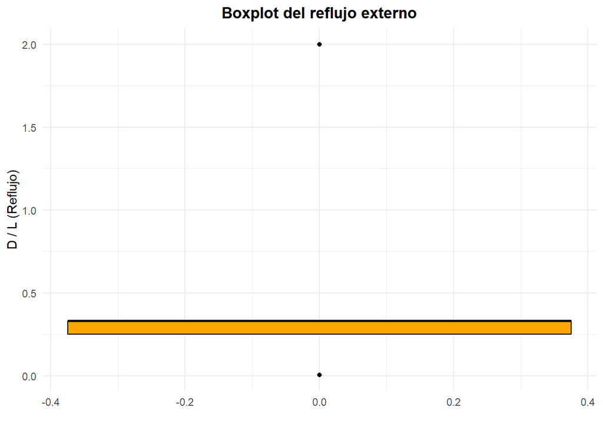

```r
ggplot(datos, aes(y = reflujo)) +
  geom_boxplot(fill = "orange", color = "black") +
  labs(title = "Boxplot del reflujo externo",
       x = "", # No hay eje x significativo para un boxplot único
       y = "D / L (Reflujo)") +
  theme_minimal() +
  theme(plot.title = element_text(hjust = 0.5, face = "bold"))
```

**Análisis Boxplotpara reflujo:**

Valor típico estable (~0.3), pero valores extremos alertan sobre desviaciones del proceso. Un reflujo promedio de 0.3 para una columna de 14 platos para lograr una separación típica de dos componentes no es un valor que pueda llamarse eficiente. Implicaría una separación muy pobre.

## 1.5 COMENTARIOS Y CONCLUSIONES

El dataset fue analizado limpiamente, con una transformación útil (reflujo). También se creó la columna de tiempo con intervalos de 0.1 h, fundamental para analizar la dinámica y estabilidad del proceso de destilación, permitiendo observar tendencias, fluctuaciones y la respuesta del sistema y la identificación de tendencias.Las visualizaciones permiten detectar eficiencia, inestabilidad y posibles fuentes de error en el proceso.Las temperaturas sugieren operación por niveles, y el análisis estadístico permite observar el comportamiento no ideal en la columna.

## 1.6 REFLEXIONES

Este proyecto ha permitido aplicar los conocimientos de limpieza, transformación y visualización de datos utilizando un conjunto de datos real, lo que facilitó enormemente la exploración de los patrones de comportamiento de la columna. Esta experiencia me reveló que R y sus librerías gráficas son potentes herramientas analíticas. La capacidad de visualizar la variación de parámetros clave en la columna de destilación me permite la comprensión del proceso.